# Replication of You call it ‘Self-Exhuberance’; I call it ‘Bragging’: Miscalibrated Predictions of Emotional Responses to Self-Promotion (Study 2) by Scopelliti, Loewenstein, Vosgerau (2015, *Psychological Science*)

Replicated by Jaclyn Schwartz; contact: jschwar2@stanford.edu

December 13, 2017

## Introduction

> Scopelliti et al., 2015 explored how self-promotion (i.e., communicating one’s positive traits) can lead to contradicting emotional perspectives. The self-promoter may perceive that the recipient feels more positive emotions and less negative emotions about the promoter’s behavior than the recipient’s true emotional reaction. These “failures of emotional perspective taking” (Scopelliti et al., 2015, p.904) can have negative consequences, where recipients may see the self-promoters as bragging. The authors argued that “people tend to underestimate differences between their own and others’ emotional reactions” by using their own emotions as “anchors to estimate” their recipient’s emotions (Scopelliti et al., 2015, p.904). They hypothesized that “self-promoters will overestimate the extent to which their behavior elicits positive emotional reactions in others, and underestimate the extent to which their behavior elicits negative emotional reactions” (Scopelliti et al., 2015, p.904).

## Methods

### Power Analysis

I used G*Power 3.1 to conduct my a priori power analysis to plan the sample size. Specifically, I used a repeated-measures ANOVA for the main within-between (emotion x condition) interaction to plan my sample size since the authors used a 2-way mixed ANOVA, with 2 (between) groups and 7 (within) measurements to calculate their effects. The authors’ reported effect size was $\eta_{p}^{2}$ = .07, which corresponds to effect size of f = .274. I set $\alpha$ = .05. In order to achieve 80% power, the yielded sample size was very small (N=16) either because the authors over-powered their sample number or the analysis yielded a huge effect. Therefore, I set the power to = .95 to increase the proposed sample size. Thus, my determined sample size is 50 to achieve 95% power.

[figure not shown]

G*power screenshot to determine sample size

### Procedure

> Participants completed a short survey on Amazon Mechanical Turk (MTurk). Participants were randomly assigned to one of two conditions: the self-promotion condition or the recipient-of-self-promotion condition. “Sample size was set to a minimum of 75 participants per condition, and the data were analyzed only after data collection had been completed. 154 Amazon Mechanical Turk workers accessed and completed a short study on personality and received $0.50 as compensation. As in Experiment 1, participants described an instance of having engaged in self-promotion or having been the recipient of someone else’s self-promotion. Next, participants in the self-promotion condition were asked to indicate the extent to which their counterpart had felt happy for, proud of, annoyed by, jealous of, angry at, upset by, and inferior to them, whereas participants in the recipient-of-self-promotion condition were asked to rate their own level of these experienced feelings” (Scopelliti et al., 2015, p.907). The between-subjects factor is “reporter” (either self-promoter **or** recipient). The emotions are considered a within-subjects factor only because participants in both conditions rate the same emotions. “All emotions were rated on 7-point scales from *not at all* (1) to *very much* (7)” (Scopelliti et al., 2015, p.907). The replication will instead recruit 25 participants per condition based on the power analysis. My pilot data suggest that the survey takes approximately 4-5 minutes to complete, so participants will receive 60 cents as compensation.

### Analysis Plan

> This experiment is a “two-cell between-subjects design” (Scopelliti et al., 2015, p.907) where participants are randomized to *either* the self-promoter or recipient-of-self-promotion conditions (between-subjects). “The authors performed a 2-way mixed ANOVA on ratings of the 7 emotional reactions” (Scopelliti et al., 2015, p.908). The *between-subjects* factor is `condition` (self-promoter vs. recipient-of-self-promotion), and the *within-subjects* factor is `emotion`. Post-hoc F-tests were performed to examine which emotions were over- or under-estimated. The topics of self-promotion (i.e., the descriptions of bragging) are categorized by 2 research assistants (RAs) only to be included as covariates. The 2 RAs independently categorized the descriptions into predefined “categories of (a) achievements; (b) individual traits and skills; (c) money, possessions, power, and status; (d) family and relationships; and (e) luck” (Scopelliti et al., 2015, p.905). These covariates are dummy coded, and “luck serves as the baseline topic” (Scopelliti et al., 2015, p.908). “Disagreements are resolved through discussion” (Scopelliti et al., 2015, p.905). Data will be excluded if participants claimed to have never bragged or if the situation described is not clearly bragging as defined by the coders. Demographic variables of gender and age seem to only be reported as sample descriptives in the original article, so this replication will follow that strategy. The main statistic the authors report is the condition x emotion interaction, *F*(6,912)=10.90, *p*<.001, $\eta_{p}^{2}$ = .07. The replication will be considered successful if the interaction is statistically significant.

**Key analysis of interest: A “2-way mixed ANOVA on ratings of the 7 emotional reactions, where emotion is the within-subjects factor, and condition is the between-subjects factor.”** As per the authors’ analyses, I will estimate the main effect of *condition* with the inclusion of topic covariates, I will estimate the main effect of *emotion* without topic covariates, and I will estimate the interaction of *condition* and *emotion* with the inclusion of topic covariates. If the interaction is significant, I will conduct post-hoc F tests to examine which emotions are over- or under-estimated.

### Differences from Original Study

The main difference is planned sample size. Another difference is that I will be one of the 2 “RAs” who code the covariate topics. For the analysis, I will include dummy coded topic covariates as separate covariates, and not as levels of one “Topic” covariate for ease of gathering the “emotion” ratings into long format.

### Methods Addendum (Post Data Collection)

#### Actual Sample

For my final data collection, I ended up recruiting 52 workers through MTurk despite requesting 50 workers, for which I haven’t figured out the reason. However, 2 workers ended up being excluded based on the exclusion criteria under “Analysis Plan.” In this case, the excluded descriptions were not bragging related. The 2nd coder and myself both agreed on this exclusion decision. The sample demographics for N=50 are analyzed as “Descriptives” under “Confirmatory analysis”.

#### Differences from pre-data collection methods plan

There were no differences from my pre-data collection methods plan. However, I did request 50 workers, and ended up with 52. After excluding 2 workers based on the exclusion criteria, however, I ended up analyzing the planned sample size of 50 workers.

## Results

The main statistic the authors report is the condition x emotion interaction, *F*(6,912)=10.90, *p*<.001, $\eta_{p}^{2}$ = .07. The main aim of the replication is to replicate this interaction. If significant, I will aim to replicate the post-hoc difference in means for each emotion to show that people in the self-promotion condition “overestimated the extent to which recipients felt happy for them (*M*=4.88, *SD*=1.78, vs. *M*=3.70, *SD*=1.91), *F*(1,145)=10.85, *p*=.001, $\eta_{p}^{2}$ = .07, and proud of them (*M*=4.33, *SD*=1.81, vs. *M*=3.08, *SD*=1.77), *F*(1,145)=12.12, *p*<.001, $\eta_{p}^{2}$ = .08”, and also “underestimated the extent to which recipients felt annoyed (*M*=3.54, *SD*=1.94, vs. *M*=4.82, *SD*=2.15), *F*(1,145)=11.56, *p*=.001, $\eta_{p}^{2}$ = .07.”

### Data preparation

Data preparation followed the analysis plan. The authors shared their materials through OSF, so I aimed to create a Qualtrics survey that precisely replicates their study 2 survey. Here is the link to the replication Qualtrics survey: https://stanforduniversity.qualtrics.com/jfe/form/SV_4O72UJKN7nEkE73

### Confirmatory analysis

#### Descriptives

```r
Npart <- length(finalData$ResponseId) # 50
finalData$Age <- as.numeric(finalData$Age)
mean_age <- mean(finalData$Age) # 32.5
sd_age <- sd(finalData$Age) # 8.894506
sd_age_r <- round(sd_age, digits = 2) # 8.89
finalData$Gender <- as.factor(finalData$Gender)
Nmale <- finalData[which(finalData$Gender == '1'), ] # 29
Nfemale <- finalData[which(finalData$Gender == '2'), ] # 21
percent_female <- (21/50)*100 # 42%
percent_male <- (29/50)*100 # 58%
```

50 participants (mean age = 32.5 years, *SD* = 8.89; 58% male, 42% female) accessed and completed a short study on personality.

#### 2-way mixed ANOVA

```r
# With Covariates (The Between-subjects factor was estimated with inclusion of the topic covariates)
Cond_aov <- aov(Rating ~ Cond + ach_dummy + poss_money_status_power_dummy + ind_skill_dummy + fam_rel_dummy + luck_dummy + Error(ResponseId), data = finalData_long)
Cond_aov_sum <- summary(Cond_aov)
print(Cond_aov_sum)
```

```
##
## Error: ResponseId
##                               Df Sum Sq Mean Sq F value  Pr(>F)
## Cond                           1   5.60    5.60   1.432 0.23781
## ach_dummy                      1   1.77    1.77   0.453 0.50427
## poss_money_status_power_dummy  1   0.86    0.86   0.220 0.64123
## ind_skill_dummy                1   0.26    0.26   0.067 0.79667
## fam_rel_dummy                  1  42.76   42.76  10.934 0.00189 **
## Residuals                     44 172.07    3.91
## ---
## Signif. codes:  0 '***' 0.001 '**' 0.01 '*' 0.05 '.' 0.1 ' ' 1
##
## Error: Within
##            Df Sum Sq Mean Sq F value Pr(>F)
## Residuals 300   1261   4.204
```

```r
# Without Covariates (The Within-subjects factor estimated without inclusion of the topic covariates)
Emo_aov_noCov <- aov(Rating ~ Emo + Error(ResponseId/(Emo)), data = finalData_long)
Emo_aov_noCov_sum <- summary(Emo_aov_noCov)
print(Emo_aov_noCov_sum)
```

```
##
## Error: ResponseId
##           Df Sum Sq Mean Sq F value Pr(>F)
## Residuals 49  223.3   4.558
##
## Error: ResponseId:Emo
##            Df Sum Sq Mean Sq F value Pr(>F)
## Emo         6  388.7   64.79   21.84 <2e-16 ***
## Residuals 294  872.4    2.97
## ---
## Signif. codes:  0 '***' 0.001 '**' 0.01 '*' 0.05 '.' 0.1 ' ' 1
```

```r
# With Covariates (The interaction was estimated with topic covariates)
mainInt <- aov(Rating ~ Cond*Emo + ach_dummy + poss_money_status_power_dummy + ind_skill_dummy + fam_rel_dummy + luck_dummy + Error(ResponseId/(Emo)), data = finalData_long)
mainInt_sum <- summary(mainInt)
print(mainInt_sum)
```

```
##
## Error: ResponseId
##                               Df Sum Sq Mean Sq F value  Pr(>F)
## Cond                           1   5.60    5.60   1.432 0.23781
## ach_dummy                      1   1.77    1.77   0.453 0.50427
## poss_money_status_power_dummy  1   0.86    0.86   0.220 0.64123
## ind_skill_dummy                1   0.26    0.26   0.067 0.79667
## fam_rel_dummy                  1  42.76   42.76  10.934 0.00189 **
## Residuals                     44 172.07    3.91
## ---
## Signif. codes:  0 '***' 0.001 '**' 0.01 '*' 0.05 '.' 0.1 ' ' 1
##
## Error: ResponseId:Emo
##            Df Sum Sq Mean Sq F value  Pr(>F)
## Emo         6  388.7   64.79   23.01 < 2e-16 ***
## Cond:Emo    6   61.3   10.22    3.63 0.00173 **
## Residuals 288  811.1    2.82
## ---
## Signif. codes:  0 '***' 0.001 '**' 0.01 '*' 0.05 '.' 0.1 ' ' 1
```

```r
knitr::kable(broom::tidy(mainInt))
```

[output not shown]

As per the authors’ analyses, I estimated the main effect of *condition* with the inclusion of topic covariates, I estimated the main effect of *emotion* without topic covariates, and I estimated the interaction with the inclusion of topic covariates. The ANOVA models indicate there is a main effect of *emotion*, *F*(6,294) = 21.83, *p*<.001, but no main effect of *condition*, *F*(1,44) = 1.43, *p* = 0.238. The two-way mixed ANOVA indicates that the *condition x emotion* interaction statistic is significant *F*(6,288) = 3.63, *p* = 0.002, $\eta_{p}^{2}$ = 0.07. Since the interaction is significant, I conducted simple effect F tests, which is in my exploratory code. I did not include age or gender in my models because the original paper does not do so.

#### Graphing the Results

```r
# Bargraph with SE bars
meanAndSem=function(x) c(mn = mean(x,na.rm=TRUE), se = sd(x,na.rm=T)/sqrt((sum(as.double(!is.na(x))))), len=sum(as.double(!is.na(x))))
Fig1 = ddply(finalData_long, .(Cond,Emo), summarize,mn = meanAndSem(Rating)[1], se = meanAndSem(Rating)[2])
Fig1 = ddply(finalData_long, .(Cond,Emo), summarize, mn = meanAndSem(Rating)[1], se = meanAndSem(Rating)[2])
limits = aes(ymax = mn + se, ymin=mn - se)
```

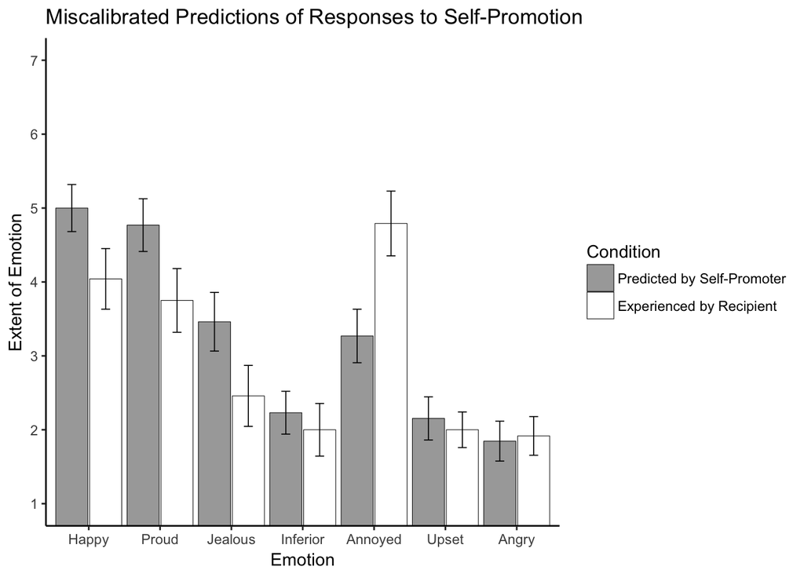

```r
Fig1$Emo = factor(
Fig1$Emo, levels = c("happy", "proud", "jealous", "inferior", "annoyed", "upset", "angry"),
labels = c("Happy", "Proud", "Jealous", "Inferior", "Annoyed", "Upset", "Angry")
)
Fig1$Cond <- factor(
  Fig1$Cond, levels=c("SP", "RSP"),
  labels=c("Predicted by Self-Promoter", "Experienced by Recipient"))
Fig1_plot = ggplot(Fig1, aes(x = factor(Emo), y = mn, fill = Cond)) +
  geom_bar(stat = 'identity', position=position_dodge(.95), size=.18,alpha = 0.7, colour="black") +
  scale_fill_manual(values = c("#808080", "#FFFFFF")) +
  labs(title = "Miscalibrated Predictions of Responses to Self-Promotion", y="Extent of Emotion",x="Emotion")+
  geom_errorbar(limits,color = 'black',position=position_dodge(.95),width=0.25, size=.3) +
  scale_y_continuous(breaks = seq(1,7,1)) +
  coord_cartesian(ylim = c(1,7,1)) +
  labs(fill = "Condition") +
  theme(axis.title=element_text(face="bold",size="14", color="black")) +
  theme(title = element_text(face = "bold")) +
  theme_classic()
print(Fig1_plot)
```

This replication graph shows “self-promoters’ predictions of recipients’ experienced emotions and recipients’ ratings of their actual experienced emotions. Error bars represent +/-1 SEM.” As per the authors’ plot, this replication plots SEM bars as opposed to 95% CI bars.

### Exploratory analyses

Since the interaction is significant, here are my exploratory post-hoc F tests.

```r
# 0 = RSP, 1 = SP (N=24 in RSP, and N=26 in SP)
SPcond <- finalData[which(finalData$Condition == '1'),]
RSPcond <- finalData[which(finalData$Condition == '0'),]
happy <- finalData_long[which(finalData_long$Emo == 'happy'),]
proud <- finalData_long[which(finalData_long$Emo == 'proud'),]
annoyed <- finalData_long[which(finalData_long$Emo == 'annoyed'),]
jealous <- finalData_long[which(finalData_long$Emo == 'jealous'),]
upset <- finalData_long[which(finalData_long$Emo == 'upset'),]
angry <- finalData_long[which(finalData_long$Emo == 'angry'),]
inferior <- finalData_long[which(finalData_long$Emo == 'inferior'),]

happy$Cond <- as.factor(happy$Cond)
proud$Cond <- as.factor(proud$Cond)
annoyed$Cond <- as.factor(annoyed$Cond)
jealous$Cond <- as.factor(jealous$Cond)
upset$Cond <- as.factor(upset$Cond)
angry$Cond <- as.factor(angry$Cond)
inferior$Cond <- as.factor(inferior$Cond)

SPcond$happy_SP <- as.numeric(SPcond$happy_SP)
SPcond$proud_SP <- as.numeric(SPcond$proud_SP)
SPcond$annoyed_SP <- as.numeric(SPcond$annoyed_SP)
SPcond$jealous_SP <- as.numeric(SPcond$jealous_SP)
SPcond$upset_SP <- as.numeric(SPcond$upset_SP)
SPcond$angry_SP <- as.numeric(SPcond$angry_SP)
SPcond$inferior_SP <- as.numeric(SPcond$inferior_SP)

RSPcond$happy_RSP <- as.numeric(RSPcond$happy_RSP)
RSPcond$proud_RSP <- as.numeric(RSPcond$proud_RSP)
RSPcond$annoyed_RSP <- as.numeric(RSPcond$annoyed_RSP)
RSPcond$jealous_RSP <- as.numeric(RSPcond$jealous_RSP)
RSPcond$upset_RSP <- as.numeric(RSPcond$upset_RSP)
RSPcond$angry_RSP <- as.numeric(RSPcond$angry_RSP)
RSPcond$inferior_RSP <- as.numeric(RSPcond$inferior_RSP)

# happy
mean(SPcond$happy_SP) # 5
```

```
## [1] 5
```

```r
sd(SPcond$happy_SP) # 1.624808
```

```
## [1] 1.624808
```

```r
mean(RSPcond$happy_RSP) # 4.041667
```

```
## [1] 4.041667
```

```r
sd(RSPcond$happy_RSP) # 2.01039
```

```
## [1] 2.01039
```

```r
summary(aov(Rating ~ Cond + ach_dummy + ind_skill_dummy + poss_money_status_power_dummy + fam_rel_dummy + luck_dummy, data = happy))
```

```
##                               Df Sum Sq Mean Sq F value Pr(>F)
## Cond                           1  11.46  11.462   3.427 0.0708 .
## ach_dummy                      1   5.76   5.762   1.723 0.1961
## ind_skill_dummy                1   3.56   3.558   1.064 0.3080
## poss_money_status_power_dummy  1   1.90   1.895   0.567 0.4556
## fam_rel_dummy                  1   0.59   0.594   0.178 0.6755
## Residuals                     44 147.15   3.344
## ---
## Signif. codes:  0 '***' 0.001 '**' 0.01 '*' 0.05 '.' 0.1 ' ' 1
```

```r
#                              Df Sum Sq Mean Sq F value Pr(>F)
#Cond                           1  11.46  11.462   3.427 0.0708 .

# proud
mean(SPcond$proud_SP) # 4.769231
```

```
## [1] 4.769231
```

```r
sd(SPcond$proud_SP) # 1.81786
```

```
## [1] 1.81786
```

```r
mean(RSPcond$proud_RSP) # 3.75
```

```
## [1] 3.75
```

```r
sd(RSPcond$proud_RSP) # 2.111048
```

```
## [1] 2.111048
```

```r
summary(aov(Rating ~ Cond + ach_dummy + ind_skill_dummy + poss_money_status_power_dummy + fam_rel_dummy + luck_dummy, data = proud))
```

```
##                               Df Sum Sq Mean Sq F value Pr(>F)
## Cond                           1  12.96  12.965   3.439 0.0704 .
## ach_dummy                      1   0.61   0.607   0.161 0.6903
## ind_skill_dummy                1   1.80   1.798   0.477 0.4934
## poss_money_status_power_dummy  1  16.41  16.414   4.355 0.0427 *
## fam_rel_dummy                  1   0.44   0.439   0.117 0.7345
## Residuals                     44 165.86   3.769
## ---
## Signif. codes:  0 '***' 0.001 '**' 0.01 '*' 0.05 '.' 0.1 ' ' 1
```

```r
#                              Df Sum Sq Mean Sq F value Pr(>F)
#Cond                           1  12.96  12.965   3.439 0.0704 .

# annoyed
mean(SPcond$annoyed_SP) # 3.269231
```

```
## [1] 3.269231
```

```r
sd(SPcond$annoyed_SP) # 1.84516
```

```
## [1] 1.84516
```

```r
mean(RSPcond$annoyed_RSP) # 4.791667
```

```
## [1] 4.791667
```

```r
sd(RSPcond$annoyed_RSP) # 2.146365
```

```
## [1] 2.146365
```

```r
summary(aov(Rating ~ Cond + ach_dummy + ind_skill_dummy + poss_money_status_power_dummy + fam_rel_dummy + luck_dummy, data = annoyed))
```

```
##                               Df Sum Sq Mean Sq F value  Pr(>F)
## Cond                           1  28.93  28.926   7.287 0.00982 **
## ach_dummy                      1   0.81   0.806   0.203 0.65454
## ind_skill_dummy                1   6.84   6.845   1.724 0.19594
## poss_money_status_power_dummy  1   0.29   0.290   0.073 0.78830
## fam_rel_dummy                  1   8.48   8.475   2.135 0.15107
## Residuals                     44 174.66   3.970
## ---
## Signif. codes:  0 '***' 0.001 '**' 0.01 '*' 0.05 '.' 0.1 ' ' 1
```

```r
#                              Df Sum Sq Mean Sq F value Pr(>F)
#Cond                           1  28.93  28.926   7.287 0.00982 **

# jealous
mean(SPcond$jealous_SP) # 3.461538
```

```
## [1] 3.461538
```

```r
sd(SPcond$jealous_SP) # 2.024466
```

```
## [1] 2.024466
```

```r
mean(RSPcond$jealous_RSP) # 2.458333
```

```
## [1] 2.458333
```

```r
sd(RSPcond$jealous_RSP) # 2.021174
```

```
## [1] 2.021174
```

```r
summary(aov(Rating ~ Cond + ach_dummy + ind_skill_dummy + poss_money_status_power_dummy + fam_rel_dummy + luck_dummy, data = jealous))
```

```
##                               Df Sum Sq Mean Sq F value Pr(>F)
## Cond                           1  12.56  12.560   3.306 0.0758 .
## ach_dummy                      1   0.67   0.674   0.177 0.6757
## ind_skill_dummy                1  11.03  11.033   2.904 0.0954 .
## poss_money_status_power_dummy  1   0.92   0.922   0.243 0.6248
## fam_rel_dummy                  1  16.62  16.622   4.375 0.0423 *
## Residuals                     44 167.17   3.799
## ---
## Signif. codes:  0 '***' 0.001 '**' 0.01 '*' 0.05 '.' 0.1 ' ' 1
```

```r
#                              Df Sum Sq Mean Sq F value Pr(>F)
#Cond                           1  12.56  12.560   3.306 0.0758 .

# upset
mean(SPcond$upset_SP) # 2.153846
```

```
## [1] 2.153846
```

```r
sd(SPcond$upset_SP) # 1.488417
```

```
## [1] 1.488417
```

```r
mean(RSPcond$upset_RSP) # 2
```

```
## [1] 2
```

```r
sd(RSPcond$upset_RSP) # 1.179536
```

```
## [1] 1.179536
```

```r
summary(aov(Rating ~ Cond + ach_dummy + ind_skill_dummy + poss_money_status_power_dummy + fam_rel_dummy + luck_dummy, data = upset))
```

```
##                               Df Sum Sq Mean Sq F value  Pr(>F)
## Cond                           1   0.30   0.295   0.182 0.67198
## ach_dummy                      1   0.06   0.058   0.036 0.85075
## ind_skill_dummy                1   0.48   0.476   0.293 0.59096
## poss_money_status_power_dummy  1   0.76   0.761   0.468 0.49732
## fam_rel_dummy                  1  14.56  14.564   8.960 0.00451 **
## Residuals                     44  71.52   1.626
## ---
## Signif. codes:  0 '***' 0.001 '**' 0.01 '*' 0.05 '.' 0.1 ' ' 1
```

```r
#                              Df Sum Sq Mean Sq F value Pr(>F)
#Cond                           1   0.30   0.295   0.182 0.67198

# angry
mean(SPcond$angry_SP) # 1.846154
```

```
## [1] 1.846154
```

```r
sd(SPcond$angry_SP) # 1.37673
```

```
## [1] 1.37673
```

```r
mean(RSPcond$angry_RSP) # 1.916667
```

```
## [1] 1.916667
```

```r
sd(RSPcond$angry_RSP) # 1.282547
```

```
## [1] 1.282547
```

```r
summary(aov(Rating ~ Cond + ach_dummy + ind_skill_dummy + poss_money_status_power_dummy + fam_rel_dummy + luck_dummy, data = angry))
```

```
##                               Df Sum Sq Mean Sq F value Pr(>F)
## Cond                           1   0.06   0.062   0.038 0.8472
## ach_dummy                      1   0.58   0.584   0.353 0.5552
## ind_skill_dummy                1   0.31   0.314   0.190 0.6652
## poss_money_status_power_dummy  1   1.66   1.662   1.006 0.3214
## fam_rel_dummy                  1   9.96   9.962   6.030 0.0181 *
## Residuals                     44  72.70   1.652
## ---
## Signif. codes:  0 '***' 0.001 '**' 0.01 '*' 0.05 '.' 0.1 ' ' 1
```

```r
#                              Df Sum Sq Mean Sq F value Pr(>F)
#Cond                           1   0.06   0.062   0.038 0.8472

# inferior
mean(SPcond$inferior_SP) # 2.230769
```

```
## [1] 2.230769
```

```r
sd(SPcond$inferior_SP) # 1.478044
```

```
## [1] 1.478044
```

```r
mean(RSPcond$inferior_RSP) # 2
```

```
## [1] 2
```

```r
sd(RSPcond$inferior_RSP) # 1.744557
```

```
## [1] 1.744557
```

```r
summary(aov(Rating ~ Cond + ach_dummy + ind_skill_dummy + poss_money_status_power_dummy + fam_rel_dummy + luck_dummy, data = inferior))
```

```
##                               Df Sum Sq Mean Sq F value Pr(>F)
## Cond                           1   0.66   0.665   0.283 0.5975
## ach_dummy                      1   0.62   0.624   0.265 0.6090
## ind_skill_dummy                1   7.89   7.885   3.356 0.0737 .
## poss_money_status_power_dummy  1   0.84   0.836   0.356 0.5538
## fam_rel_dummy                  1  11.89  11.887   5.059 0.0296 *
## Residuals                     44 103.38   2.350
## ---
## Signif. codes:  0 '***' 0.001 '**' 0.01 '*' 0.05 '.' 0.1 ' ' 1
```

```r
#                              Df Sum Sq Mean Sq F value Pr(>F)
#Cond                           1   0.66   0.665   0.283 0.5975
```

Self-promoters marginally overestimated the extent to which recipients felt **happy** for them (*M*=5, *SD*=1.62, vs. *M*=4.04, *SD*=2.01), *F*(1,44) = 3.43, *p*=.071, **proud** of them (*M*=4.77, *SD*=1.82 vs. *M*=3.75, *SD*=2.11), *F*(1,44) = 3.44, *p*= .070, and **jealous** of them (*M*=3.46, *SD*=2.02 vs. *M*=2.46, *SD*=2.02), *F*(1,44) = 3.31, *p*= .076. However self-promoters significantly underestimated the extent to which recipients felt **annoyed** by them (*M*=3.27, *SD*=1.85 vs. *M*=4.79, *SD*=2.14), *F*(1,44) = 7.29, *p*=.010. In this replication there was no difference in ratings of recipients feeling **upset** (*M*=2.15, *SD*=1.49, vs. *M*=2, *SD*=1.18), *F*(1,44) = 0.18, *p*=.672, **angry** (*M*=1.85, *SD*=1.38, vs. *M*=1.92, *SD*=1.28), *F*(1,44) = 0.04, *p*=.847, and **inferior** (*M*=2.23, *SD*=1.48, vs. *M*=2, *SD*=1.74), *F*(1,44) = .28, *p*=.598.

##### Exploratory individual participant plots

I’ve constructed an additional plot showing individual variation grouped by type of emotion and condition.

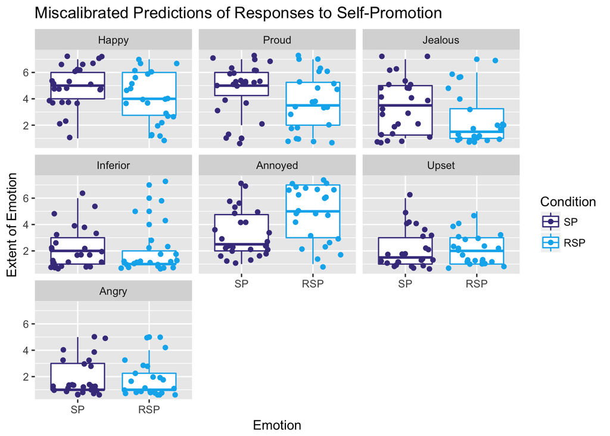

```r
finalData_long$Emo = factor(
finalData_long$Emo, levels = c("happy", "proud", "jealous", "inferior", "annoyed", "upset", "angry"),
labels = c("Happy", "Proud", "Jealous", "Inferior", "Annoyed", "Upset", "Angry")
)
finalData_long$Cond <- factor(
  finalData_long$Cond, levels=c("SP", "RSP"),
  labels=c("SP", "RSP"))
ggplot(finalData_long, aes(x = Cond, y = Rating, color=Cond)) +
  geom_boxplot() +
  scale_color_manual(values = c("#473C8B", "#00B2EE")) +
  geom_jitter() +
  facet_wrap(~factor(Emo)) +
  labs(title = "Miscalibrated Predictions of Responses to Self-Promotion", y="Extent of Emotion",x="Emotion") +
  labs(color = "Condition")
```

## Discussion

### Summary of Replication Attempt

The primary result I aimed to replicate was the condition x emotion interaction, *F*(6,912)=10.90, *p*<.001, $\eta_{p}^{2}$ = 0.07. The condition x emotion interaction based on my confirmatory analysis is in fact significant, *F*(6,288) = 3.63, *p* = 0.002, $\eta_{p}^{2}$ = 0.07, such that self-promoters and recipients differed in their ratings of emotion. Based on my analysis plan, I consider the replication successful.

### Commentary

1. The follow-up simple effect post-hoc F tests partially replicated the authors’ results and partially confirms their hypotheses that self-promoters overestimate the extent to which their behavior elicits positive emotional reactions in others, and underestimate the extent to which their behavior elicits negative emotional reactions. The data for this replication suggests that self-promoters *marginally* overestimated the extent to which recipients felt **happy** for them (*p*=.071), **proud** of them (*p*= .070), and **jealous** of them (*p*= .076), whereas the authors found that self-promoters *significantly* overestimated the extent to which recipients felt **happy** for them, **proud** of them, and **jealous** of them. The replication data successfully replicated the authors’ finding that self-promoters *significantly* underestimated the extent to which recipients felt **annoyed** (*p*=.010). The replication also successfully replicated the authors’ findings that there was *no difference* in ratings of feeling **anger** (*p*=.847) or **upset** (*p*=.672). However, I did not replicate the finding that self-promoters *marginally* overestimated the extent to which recipients felt **inferior**. In fact, I found no difference (*p*=.598).
2. Although the post-hoc tests were partially replicated, I considered this replication successful, since according to my analysis plan, I aimed to replicate the interaction of condition and emotion. The partial replication could be influenced by the coding of covariates. It’s possible that certain topics elicit higher ratings of certain emotions than others. However, I don’t expect that this would affect the interaction since topic variables were covaried. Exploring the effects of covariates would require further exploration.
3. The replication attempt did not have any objections or challenges.

### Reference

Scopelliti, I., Loewenstein, G., & Vosgerau, J. (2015). You Call It “Self-Exuberance”; I Call It “Bragging”: Miscalibrated Predictions of Emotional Responses to Self-Promotion. Psychological Science, 1–12. https://doi.org/10.1177/0956797615573516